# ML

```python
import datetime
import pandas as pd
from pandas import DataFrame
import numpy as np
from sklearn.decomposition import PCA
import random
import ml_metrics as metrics
import matplotlib.pyplot as plt
from sklearn.cross_validation import train_test_split
```

```python
# load datasets
destinations = pd.read_csv("destinations.csv")
train = pd.read_csv("train.csv")
```

```python
# get year and month attributes from date_time
train["date_time"] = pd.to_datetime(train["date_time"])
train["year"] = train["date_time"].dt.year
train["month"] = train["date_time"].dt.month
```

```python
train.shape
```

```
(37670293, 26)
```

```python
m=train.orig_destination_distance.mean()
train.orig_destination_distance.fillna(m, inplace=True)
```

```python
# random 100000 samples
unique_users = train.user_id.unique()
print len(unique_users)
```

```
1198786
```

```python
selected_user_id = random.sample(unique_users,100000)
selected_train = train[train.user_id.isin(selected_user_id)]
# selected_train = train
```

```python
selected_train.shape
```

```
(3134118, 26)
```

```python
#selected_train.head(5)
```

[output not shown]

```python
# train = 2013 | until July 2014;
# test = After July 2014
# train2 = selected_train[((selected_train.year == 2013) | ((selected_train.year == 2014) & (selected_train.month < 8)))]
# test2 = selected_train[((selected_train.year == 2014) & (selected_train.month >= 8))]
```

```python
size = len(selected_train)
train2 = selected_train[ : int(size*.80)]
test2 = selected_train[int(size*.80)+1 : ]
print size
print len(train2)
print len(test2)
```

```
3134118
2507294
626823
```

```python
train2.head(5)
```

|  | date_time | site_name | posa_continent | user_location_country | user_location_region | user_location_city | orig_destination_distance | user_id | is_mobile | is_package | ... | srch_destination_id | srch_destination_type_id | is_booking | cnt | hotel_continent | hotel_country | hotel_market | hotel_cluster | year | month |
| --- | --- | --- | --- | --- | --- | --- | --- | --- | --- | --- | --- | --- | --- | --- | --- | --- | --- | --- | --- | --- | --- |
| 355 | 2014-06-03 10:38:09 | 2 | 3 | 55 | 405 | 38988 | 1970.090027 | 2677 | 0 | 0 | ... | 8746 | 1 | 0 | 1 | 6 | 105 | 29 | 57 | 2014 | 6 |
| 356 | 2014-06-03 10:41:10 | 2 | 3 | 55 | 405 | 38988 | 1970.090027 | 2677 | 0 | 0 | ... | 8746 | 1 | 0 | 1 | 6 | 105 | 29 | 35 | 2014 | 6 |
| 357 | 2014-06-03 10:42:21 | 2 | 3 | 55 | 405 | 38988 | 1970.090027 | 2677 | 0 | 0 | ... | 8746 | 1 | 0 | 1 | 6 | 105 | 29 | 89 | 2014 | 6 |
| 358 | 2014-06-03 10:42:41 | 2 | 3 | 55 | 405 | 38988 | 1970.090027 | 2677 | 0 | 0 | ... | 8746 | 1 | 0 | 1 | 6 | 105 | 29 | 89 | 2014 | 6 |
| 359 | 2014-06-03 10:54:05 | 2 | 3 | 55 | 405 | 38988 | 1970.090027 | 2677 | 0 | 0 | ... | 8746 | 1 | 0 | 1 | 6 | 105 | 29 | 89 | 2014 | 6 |

5 rows × 26 columns

```python
# only get those whose booking is true
test2 = test2[test2.is_booking == True]
```

```python
print "train2 - ", len(train2)
print "test2 - ", len(test2)
```

```
train2 -  2507294
test2 -  49375
```

```python
def map5eval(preds, actual):
    predicted = preds.argsort(axis=1)[:,-np.arange(5)]
    metric = 0.
    for i in range(5):
        metric += np.sum(actual==predicted[:,i])/(i+1)
    metric /= actual.shape[0]
    return metric
```

### Base Case

```python
most_common_clusters = list(train.hotel_cluster.value_counts().head().index)
predictions = [most_common_clusters for i in range(test2.shape[0])]
```

```python
most_common_clusters
```

```
[91, 41, 48, 64, 65]
```

```python
target = [[l] for l in test2["hotel_cluster"]]
print "Base case evaluation: ", metrics.mapk(target, predictions, k=5)
```

```
Base case evaluation:  0.0623362025316
```

### Generate features from destinations csv

```python
pca = PCA(n_components=3)
dest_small = pca.fit_transform(destinations[["d{0}".format(i + 1) for i in range(149)]])
dest_small = pd.DataFrame(dest_small)
dest_small["srch_destination_id"] = destinations["srch_destination_id"]
```

```python
# dest_small
```

### Feature Engineering

- Generate new date features based on date_time, srch_ci, and srch_co.
- Remove non-numeric columns like date_time.
- Add in features from dest_small.
- Replace any missing values with -1.
- Calculate features such as length of stay, check in day, and check out month.

```python
def calc_fast_features(df):
    df.loc[:,'date_time'] = pd.to_datetime(df["date_time"])
    df.loc[:,'srch_ci'] = pd.to_datetime(df["srch_ci"], format='%Y-%m-%d', errors="coerce")
    df.loc[:,'srch_co'] = pd.to_datetime(df["srch_co"], format='%Y-%m-%d', errors="coerce")

    props = {}
    for prop in ["month", "day", "hour", "minute", "dayofweek", "quarter"]:
        props[prop] = getattr(df["date_time"].dt, prop)

    carryover = [p for p in df.columns if p not in ["date_time", "srch_ci", "srch_co"]]
    for prop in carryover:
        props[prop] = df[prop]

    date_props = ["month", "day", "dayofweek", "quarter"]
    for prop in date_props:
        props["ci_{0}".format(prop)] = getattr(df["srch_ci"].dt, prop)
        props["co_{0}".format(prop)] = getattr(df["srch_co"].dt, prop)
    props["stay_span"] = (df["srch_co"] - df["srch_ci"]).astype('timedelta64[h]')

    ret = pd.DataFrame(props)

    ret = ret.join(dest_small, on="srch_destination_id", how='left', rsuffix="dest")
    ret = ret.drop("srch_destination_iddest", axis=1)
    return ret

df = calc_fast_features(train2)
df.fillna(-1, inplace=True)
```

### Random Forest

```python
predictors = [c for c in df.columns if c not in ["hotel_cluster"]]
from sklearn import model_selection
from sklearn.ensemble import RandomForestClassifier

# clf = RandomForestClassifier(n_estimators=10, min_weight_fraction_leaf=0.1)
clf = RandomForestClassifier(n_estimators=31,max_depth=10,random_state=123)
scores = model_selection.cross_val_score(clf, df[predictors], df['hotel_cluster'], cv=5)
print "Random Forest: ", scores
```

```
Random Forest:  [ 0.12409321  0.12402713  0.12409315  0.12567605  0.12561949]
```

```python
clf.fit(df[predictors], df['hotel_cluster'])
```

```
RandomForestClassifier(bootstrap=True, class_weight=None, criterion='gini',
            max_depth=10, max_features='auto', max_leaf_nodes=None,
            min_impurity_decrease=0.0, min_impurity_split=None,
            min_samples_leaf=1, min_samples_split=2,
            min_weight_fraction_leaf=0.0, n_estimators=31, n_jobs=1,
            oob_score=False, random_state=123, verbose=0, warm_start=False)
```

```python
importance = clf.feature_importances_
indices=np.argsort(importance)[::-1][:10]
```

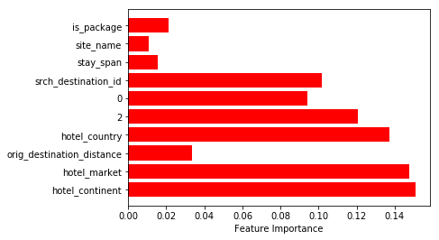

```python
plt.barh(range(10), importance[indices],color='r')
plt.yticks(range(10),df[predictors].columns[indices])
plt.xlabel('Feature Importance')
plt.show()
```

```python
clf.classes_
```

```
array([ 0,  1,  2,  3,  4,  5,  6,  7,  8,  9, 10, 11, 12, 13, 14, 15, 16,
       17, 18, 19, 20, 21, 22, 23, 24, 25, 26, 27, 28, 29, 30, 31, 32, 33,
       34, 35, 36, 37, 38, 39, 40, 41, 42, 43, 44, 45, 46, 47, 48, 49, 50,
       51, 52, 53, 54, 55, 56, 57, 58, 59, 60, 61, 62, 63, 64, 65, 66, 67,
       68, 69, 70, 71, 72, 73, 74, 75, 76, 77, 78, 79, 80, 81, 82, 83, 84,
       85, 86, 87, 88, 89, 90, 91, 92, 93, 94, 95, 96, 97, 98, 99])
```

```python
dict_cluster = {}
for (k,v) in enumerate(clf.classes_):
    dict_cluster[k] = v
# dict_cluster
```

```python
t2 = calc_fast_features(test2)
t2.fillna(-1, inplace=True)
```

```python
testPredictors = [c for c in t2.columns if c not in ["hotel_cluster"]]
```

```python
y_pred=clf.predict_proba(t2[testPredictors])
#take largest 5 probablities' indexes
a=y_pred.argsort(axis=1)[:,-5:]
```

```python
y_pred
```

```
array([[  7.08618033e-03,   2.27638991e-03,   2.72010353e-02, ...,
          7.53145097e-03,   2.75503165e-02,   1.71702490e-02],
       [  6.80354151e-03,   2.31778740e-03,   2.73095952e-02, ...,
          7.56704019e-03,   2.76049226e-02,   1.71483368e-02],
       [  4.37339736e-03,   2.43685448e-02,   1.12667315e-02, ...,
          3.87767529e-03,   7.26712267e-03,   6.21925908e-03],
       ...,
       [  1.90758950e-03,   7.49888929e-05,   2.79914038e-02, ...,
          9.82027307e-03,   6.74319834e-02,   1.49085779e-02],
       [  3.99808657e-03,   3.78337218e-05,   4.18739448e-02, ...,
          7.53364742e-03,   5.38381801e-03,   2.74263794e-02],
       [  2.85321423e-03,   2.95820266e-06,   4.24728075e-02, ...,
          1.56406328e-02,   5.32456830e-02,   2.18253444e-02]])
```

```python
a
```

```
array([[98,  9, 59, 68, 95],
       [98,  9, 59, 68, 95],
       [28, 16, 42, 48, 91],
       ...,
       [ 9, 59, 95, 68, 98],
       [59, 36, 90, 62, 58],
       [59,  9, 98, 95, 68]])
```

```python
#take the corresonding cluster of the 5 top indices
b = []
for i in a.flatten():
    b.append(dict_cluster.get(i))
```

```python
cluster_pred = np.array(b).reshape(a.shape)
```

```python
cluster_pred
```

```
array([[98,  9, 59, 68, 95],
       [98,  9, 59, 68, 95],
       [28, 16, 42, 48, 91],
       ...,
       [ 9, 59, 95, 68, 98],
       [59, 36, 90, 62, 58],
       [59,  9, 98, 95, 68]])
```

```python
target = [[l] for l in t2["hotel_cluster"]]
```

```python
print "Random Forest score: ",metrics.mapk(target,cluster_pred,k=5)
```

```
Random Forest score:  0.143055864979
```

```python
map5 = map5eval(y_pred, t2['hotel_cluster'])
map5
```

```
0.11809620253164557
```

### Binary Classifiers

```python
# from sklearn.ensemble import RandomForestClassifier
# from sklearn.model_selection import KFold
# from itertools import chain

# all_probs = []
# unique_clusters = df["hotel_cluster"].unique()
# for cluster in unique_clusters:
#     df["target"] = 1
#     df["target"][df["hotel_cluster"] != cluster] = 0
# #     print df["target"]
#     predictors = [col for col in df if col not in ['hotel_cluster', "target"]]
#     probs = []
#     kf = KFold(n_splits=2)
#     cv = kf.split(df["target"])
#     clf = RandomForestClassifier(n_estimators=10, min_weight_fraction_leaf=0.1)
#     for i, (tr, te) in enumerate(cv):
#         clf.fit(df[predictors].iloc[tr], df["target"].iloc[tr])
#         preds = clf.predict_proba(df[predictors].iloc[te])
#         probs.append([p[1] for p in preds])
#     full_probts = chain.from_iterable(probs)
#     all_probs.append(list(full_probs))

# prediction_frame = pd.DataFrame(all_probs).T
# prediction_frame.columns = unique_clusters
# def find_top_5(row):
#     return list(row.nlargest(5).index)

# preds = []
# for index, row in prediction_frame.iterrows():
#     preds.append(find_top_5(row))

# print "test2222", test2.iloc[:,"hotel_cluster"]
# print metrics.mapk([[l] for l in test2.iloc["hotel_cluster"]], preds, k=5)
```

### SGD Classifier

```python
from sklearn import linear_model

clf = linear_model.SGDClassifier(loss='log', n_jobs=-1, alpha=0.0000025, verbose=0)
sgdScores = model_selection.cross_val_score(clf, df[predictors], df['hotel_cluster'], cv=3)
print "SGD Classifier: ", sgdScores
```

[output not shown]

```python
# clf.fit(df[predictors], df['hotel_cluster'])
clf.partial_fit(df[predictors], df['hotel_cluster'], classes=np.arange(100))
```

```
SGDClassifier(alpha=2.5e-06, average=False, class_weight=None, epsilon=0.1,
       eta0=0.0, fit_intercept=True, l1_ratio=0.15,
       learning_rate='optimal', loss='log', max_iter=None, n_iter=None,
       n_jobs=-1, penalty='l2', power_t=0.5, random_state=None,
       shuffle=True, tol=None, verbose=0, warm_start=False)
```

```python
#predictors
```

```python
clf.classes_
```

```
array([ 0,  1,  2,  3,  4,  5,  6,  7,  8,  9, 10, 11, 12, 13, 14, 15, 16,
       17, 18, 19, 20, 21, 22, 23, 24, 25, 26, 27, 28, 29, 30, 31, 32, 33,
       34, 35, 36, 37, 38, 39, 40, 41, 42, 43, 44, 45, 46, 47, 48, 49, 50,
       51, 52, 53, 54, 55, 56, 57, 58, 59, 60, 61, 62, 63, 64, 65, 66, 67,
       68, 69, 70, 71, 72, 73, 74, 75, 76, 77, 78, 79, 80, 81, 82, 83, 84,
       85, 86, 87, 88, 89, 90, 91, 92, 93, 94, 95, 96, 97, 98, 99])
```

```python
dict_cluster = {}
for (k,v) in enumerate(clf.classes_):
    dict_cluster[k] = v
```

```python
y_pred=clf.predict_proba(t2[testPredictors])
#take largest 5 probablities' indexes
a=y_pred.argsort(axis=1)[:,-5:]
```

```python
y_pred
```

```
array([[ 0.,  0.,  0., ...,  0.,  0.,  0.],
       [ 0.,  0.,  0., ...,  0.,  0.,  0.],
       [ 0.,  0.,  0., ...,  0.,  0.,  0.],
       ...,
       [ 0.,  0.,  0., ...,  0.,  0.,  0.],
       [ 0.,  0.,  0., ...,  0.,  0.,  0.],
       [ 0.,  0.,  0., ...,  0.,  0.,  0.]])
```

```python
a
```

```
array([[27, 36, 99, 10, 43],
       [27, 36, 99, 10, 43],
       [27, 36, 99, 10, 43],
       ...,
       [27, 36, 99, 10, 43],
       [27, 36, 99, 10, 43],
       [27, 36, 99, 10, 43]])
```

```python
#take the corresonding cluster of the 5 top indices
b = []
for i in a.flatten():
    b.append(dict_cluster.get(i))
```

```python
cluster_pred = np.array(b).reshape(a.shape)
```

```python
cluster_pred
```

```
array([[27, 36, 99, 10, 43],
       [27, 36, 99, 10, 43],
       [27, 36, 99, 10, 43],
       ...,
       [27, 36, 99, 10, 43],
       [27, 36, 99, 10, 43],
       [27, 36, 99, 10, 43]])
```

```python
target = [[l] for l in t2["hotel_cluster"]]
```

```python
print "Stochastic Gradient Descent (SGD) score: ",metrics.mapk(target,cluster_pred,k=5)
```

```
Stochastic Gradient Descent (SGD) score:  0.0173275949367
```

```python
map5 = map5eval(y_pred, t2['hotel_cluster'])
map5
```

```
0.021164556962025318
```

### Naive Bayes

```python
from sklearn.naive_bayes import BernoulliNB

clf = BernoulliNB(alpha=1.0)
nbScores = model_selection.cross_val_score(clf, df[predictors], df['hotel_cluster'], cv=3)
print "Naive Bayes: ", nbScores
```

```
Naive Bayes:  [ 0.04427152  0.04462357  0.04570387]
```

```python
# clf.fit(df[predictors], df['hotel_cluster'])
clf.partial_fit(df[predictors], df['hotel_cluster'], classes=np.arange(100))

dict_cluster = {}
for (k,v) in enumerate(clf.classes_):
    dict_cluster[k] = v

y_pred=clf.predict_proba(t2[testPredictors])
#take largest 5 probablities' indexes
a=y_pred.argsort(axis=1)[:,-5:]

print "nb_a:", a

#take the corresonding cluster of the 5 top indices
b = []
for i in a.flatten():
    b.append(dict_cluster.get(i))

cluster_pred = np.array(b).reshape(a.shape)
target = [[l] for l in t2["hotel_cluster"]]
print "Naive Bayes score: ",metrics.mapk(target,cluster_pred,k=5)
```

```
nb_a: [[95 68  9  2 59]
 [95 68  9  2 59]
 [59 28 42 48 91]
 ...,
 [95 98 68  2 59]
 [95  2 68 98 59]
 [ 2 98 68  9 59]]
Naive Bayes score:  0.0636189029536
```

```python
map5 = map5eval(y_pred, t2['hotel_cluster'])
map5
```

```
0.04710886075949367
```

### Improvements

- Aggregate `hotel_cluster` based on `srch_destination_id`

  > find the most popular hotel clusters for each destination to predict that a user who searches for a destination is going to one of the most popular hotel clusters for that destination
- Group training data by `search_destination_id` and `hotel_cluster`
- Iterate each group
  > - Assign 1 point to each hotel cluster where `is_booking` is True.
  > - Assign .15 points to each hotel cluster where `is_booking` is False.
  > - Assign the score to the `srch_destination_id` / `hotel_cluster` combination in a dictionary.

#### Output:

We'll have a dictionary where each key is a `srch_destination_id`. Each value in the dictionary will be another dictionary, containing `hotel_clusters` as keys with scores as values

```python
def make_key(items):
    return "_".join([str(i) for i in items])

match_cols = ["srch_destination_id"]
cluster_cols = match_cols + ['hotel_cluster']
groups = train2.groupby(cluster_cols)
top_clusters = {}
for name, group in groups:
    clicks = len(group.is_booking[group.is_booking == False])
    bookings = len(group.is_booking[group.is_booking == True])

    score = bookings + .15 * clicks

    clus_name = make_key(name[:len(match_cols)])
    if clus_name not in top_clusters:
        top_clusters[clus_name] = {}
    top_clusters[clus_name][name[-1]] = score
```

```python
top_clusters
```

```
{'11542': {91: 3.5999999999999996},
 '11543': {27: 2.2},
 '11547': {6: 2.05,
  7: 0.75,
  8: 5.15,
  10: 0.8999999999999999,
  13: 3.6999999999999997,
  15: 1.2,
  16: 0.3,
  17: 4.15,
  27: 2.25,
  30: 0.44999999999999996,
  32: 0.6,
  33: 2.25,
  39: 1.45,
```

[output cut: 5294 more lines]

### Find top 5 clusters for each `srch_destination_id`

- Loop through each key in top_clusters.
- Find the top 5 clusters for that key.
- Assign the top 5 clusters to a new dictionary, cluster_dict

```python
import operator

cluster_dict = {}
for n in top_clusters:
    tc = top_clusters[n]
    top = [l[0] for l in sorted(tc.items(), key=operator.itemgetter(1), reverse=True)[:5]]
    cluster_dict[n] = top
```

```python
cluster_dict
```

```
{'11542': [91],
 '11543': [27],
 '11547': [80, 50, 8, 75, 17],
 '5989': [44, 67, 78],
 '19397': [60, 57],
 '5980': [82, 42, 48, 7, 50],
 '19394': [78],
 '5986': [33],
 '19392': [58, 89, 3, 44],
 '19391': [60],
 '5985': [48, 13],
 '36709': [60],
 '46139': [44],
 '46137': [53, 30],
 '46136': [53, 30, 60, 44, 20],
 '46135': [30, 44],
 '46132': [53, 44, 20, 78],
 '46130': [63, 58, 3, 53, 30],
 '36707': [38],
 '19971': [76],
 '273': [82, 25, 44, 43, 76],
 '19977': [85],
 '276': [53],
 '19974': [44, 3, 78, 20, 86],
 '278': [8],
 '16704': [2, 6, 33, 83, 34],
 '16707': [87, 17, 92, 86],
 '16706': [32],
 '16701': [58, 38, 89, 60, 90],
 '12019': [34, 65, 63, 78, 73],
 '12018': [91, 48, 10, 11, 42],
 '12015': [32, 28, 42, 48, 50],
 '12014': [91, 16, 15, 72, 42],
 '12017': [91, 72, 2, 4, 41],
 '12016': [91, 42, 16, 77, 25],
 '12011': [91, 50, 48, 94, 68],
 '12010': [42, 91, 94, 51, 28],
 '12013': [7, 82, 42, 32, 91],
 '12012': [42, 48, 47, 29, 91],
 '64674': [90],
```

[output cut: 946 more lines]

```
 '22955': [42, 7, 72, 91, 94],
 '56979': [20],
 '2741': [82],
 '2742': [14],
 '2744': [6, 58, 75, 82, 93],
 '2749': [82, 61],
 '2748': [29],
 '37304': [36, 62],
 '37307': [8, 30, 5],
 '54727': [20, 44, 30],
 '54726': [94],
 '54721': [87],
 '3048': [6, 43, 15, 81, 28],
 '62634': [39],
 ...}
```

### Make predictions based on destination

- Iterate each test data
- Extract `srch_destination_id` for the row
- Find top clusters for that `srch_destination_id`
- Append top clusters to preds

#### Output

`preds` - a list of lists containing predictions

```python
preds = []
for index, row in test2.iterrows():
    key = make_key([row[m] for m in match_cols])
    if key in cluster_dict:
        preds.append(cluster_dict[key])
    else:
        preds.append([])
```

#### Calculate error

```python
metrics.mapk([[l] for l in test2["hotel_cluster"]], preds, k=5)
```

```
0.30150075949367083
```

### Finding matching users

Finding users in training set that matches in testing set

- Split the training data into groups based on the match columns.
- Loop through the testing data.
- Create an index based on the match columns.
- Get any matches between the testing data and the training data using the groups.

```python
match_cols = ['user_location_country', 'user_location_region', 'user_location_city', 'hotel_market', 'orig_destination_distance']

groups = train2.groupby(match_cols)

def generate_exact_matches(row, match_cols):
    index = tuple([row[t] for t in match_cols])
    try:
        group = groups.get_group(index)
    except Exception:
        return []
    clus = list(set(group.hotel_cluster))
    return clus

exact_matches = []
for i in range(test2.shape[0]):
    exact_matches.append(generate_exact_matches(test2.iloc[i], match_cols))
```

### Combining predictions

```python
def f5(seq, idfun=None):
    if idfun is None:
        def idfun(x): return x
    seen = {}
    result = []
    for item in seq:
        marker = idfun(item)
        if marker in seen: continue
        seen[marker] = 1
        result.append(item)
    return result

full_preds = [f5(exact_matches[p] + preds[p] + most_common_clusters)[:5] for p in range(len(preds))]
metrics.mapk([[l] for l in test2["hotel_cluster"]], full_preds, k=5)
```

```
0.35600033755274268
```